# Property price analasys (Tölvuverkefni 2)

Óðinn Eldon Ragnarsson (oer2@hi.is) and Oren Raz (orr3@hi.is)

15.2.2020

Importing libraries needed

```r
library(tidyverse)
library(readr)
library(dplyr)
library(ggplot2)
library(knitr)
```

## a)

First we read the csv file and create a database to work with within R. We then rename the columns of the database to be more readable names. The data in question was published by “Þjóðskrá Íslands” in October 2016 regarding property prices in 2017.

```r
oo <- read.csv(file = 'husnaedi.csv', fileEncoding = "UTF-8", sep =';')
oo = oo %>% rename("curent_value" = "nuvirdi",
                   "type" = "teg_eign",
                   "area" = "matssvaedi",
                   "size" = "ibm2",)
```

We pick a seed based on our birhtdays to use to determine which area we will work with. We will only use properties of the type “Íbúðareign” so other entries are filtered out. Finally we remove the type column as it is no longer needed.

```r
set.seed(0601)
hverfi<-sample(c(20,90,100),1)
oo <- oo%>%filter(area==hverfi)
oo <- subset(oo, select = -c(area))
oo <- filter(oo, type =="Íbúðareign")
oo <- subset(oo, select = -c(type))
```

As the seed is fixed the same area will be selected every time, in our case 90. But we don’t need this variable anymore so we’ll remove it.

## b)

Here we have a histogram that shows the price distribution of properties.

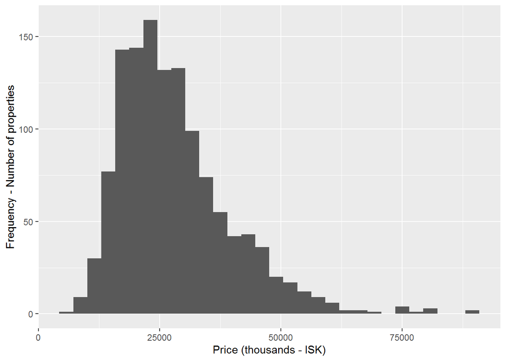

```r
ggplot(oo, aes( x=curent_value)) +
  geom_histogram()+xlab("Price (thousands - ISK)")+ylab("Frequency - Number of properties")
```

```r
price_mean = mean(oo$curent_value)
```

## C)

here we will demonstrate how the mean converges onto a single value with a larger and larger sample size. This information can very very important to wee whether a mean really tells you something about a data set or wether the mean is taken before the mean converges. As before we will need a seed to ensre that the plot is the same every time.

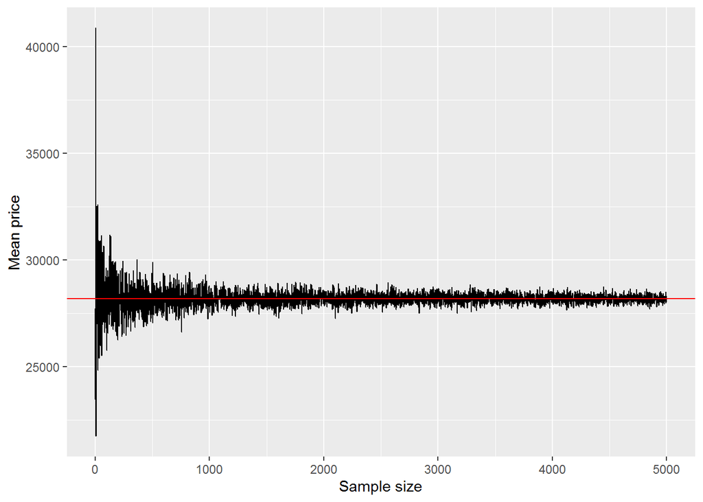

```r
set.seed(0601)
someVector <- sapply((1:5000),
  function(x) {mean(sample(oo$curent_value, x,replace = TRUE))})

qplot(x = 1:5000,
      y = someVector,
      geom="line")+ xlab("Sample size")+ ylab("Mean price") +
      geom_hline(yintercept = price_mean, col="red")
```

This is the law of large numbers at work. Note that the database only contains 1256 values so we are reusing values to create the full plot.

## d)

Here we create four vectors with 10000 entries. Each entry contains the average of n random prices. We use n = 2, 5, 20, 400.

```r
staerd <- c(2,5,20,400)
staerd1 <- replicate(n = 10000, mean(sample(oo$curent_value,
        staerd[1],replace = TRUE)),simplify = TRUE )
staerd2 <- replicate(n = 10000, mean(sample(oo$curent_value,
        staerd[2],replace = TRUE)),simplify = TRUE )
staerd3 <- replicate(n = 10000, mean(sample(oo$curent_value,
        staerd[3],replace = TRUE)),simplify = TRUE )
staerd4 <- replicate(n = 10000, mean(sample(oo$curent_value,
        staerd[4],replace = TRUE)),simplify = TRUE )
remove(staerd)
```

## e)

These vectors can also be used to illustrate the convergence towards a mean or expected value with larger and larger sample sizes. These four histograms show how with larger sample sizes the distribution gets closer and closer to the expected value.

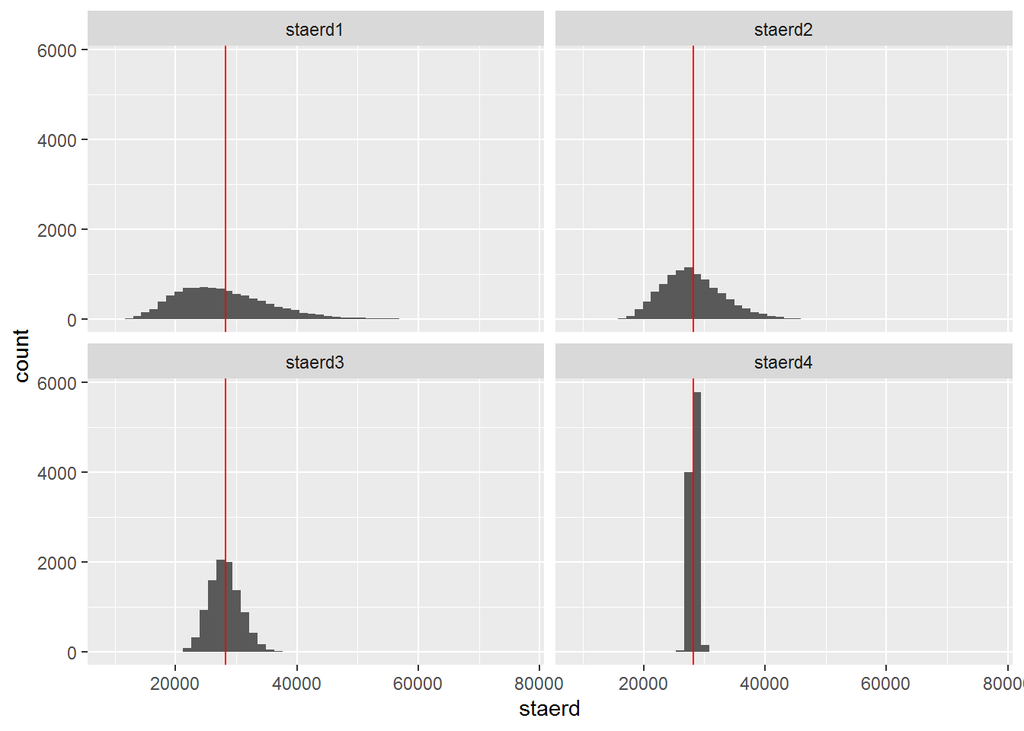

```r
num <- c(1:10000)
staerd <- tibble(num,staerd1=staerd1, staerd2 = staerd2,
                 staerd3 = staerd3,staerd4=staerd4)
remove(staerd1,staerd2,staerd3,staerd4)

st <- gather(staerd,key="sample", value=staerd,
            c(staerd1,staerd2,staerd3,staerd4))

#works ggplot
ggplot(data = st, aes(x = staerd)) +
    geom_histogram(bins=50)+geom_vline(xintercept = price_mean, col="red")+ ##facet_wrap(~sample)
  facet_wrap(~sample, nrow = 2, ncol = 2, scales = "fixed",
             shrink = TRUE, labeller = "label_value", as.table = TRUE,
             switch = NULL, drop = TRUE, dir = "h", strip.position = "top")
```

## f)

Here we have the same tables with the scales free so the axes adapt to the data. Note how for larger sample sizes i.e. “staerd3” and “staerd4” the data forms a normal distribution centered around the mean with smaller and smaller variances.

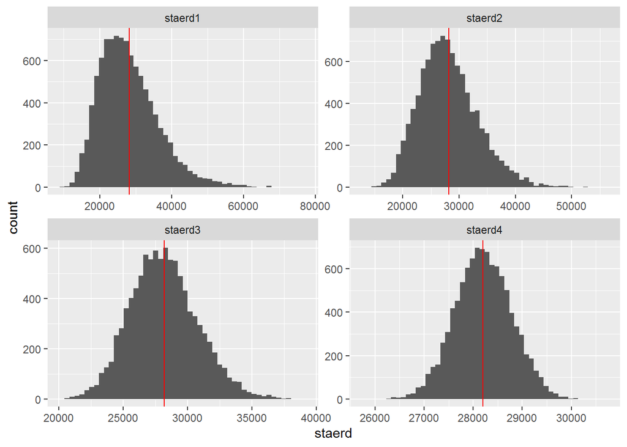

```r
ggplot(data = st, aes(x = staerd)) +
  geom_histogram(bins=50)+geom_vline(xintercept = price_mean, col="red")+
  facet_wrap(~sample, nrow = 2, ncol = 2, scales = "free",
             shrink = TRUE, labeller = "label_value", as.table = TRUE,
             switch = NULL, drop = TRUE, dir = "h", strip.position = "top")
```

## g)

```r
tolfr <- tibble(item=c("n = 2", "n = 5", "n = 20", "n = 400", "dataframe"),
 mean = c(mean(staerd$staerd1), mean(staerd$staerd2),
 mean(staerd$staerd3), mean(staerd$staerd4), mean(oo$curent_value)),
 variance = c(var(staerd$staerd1), var(staerd$staerd2),
 var(staerd$staerd3), var(staerd$staerd4), var(oo$curent_value)))
knitr::kable(tolfr,
  align = 'ccc', table.attr = "class=\"table\"",
  format = "html")
```

| item | mean | variance |
| --- | --- | --- |
| n = 2 | 28193.11 | 68190067.4 |
| n = 5 | 28131.24 | 27023220.4 |
| n = 20 | 28159.90 | 6874213.0 |
| n = 400 | 28208.03 | 332427.8 |
| dataframe | 28195.54 | 134802511.8 |

## h)

Central Limit Theorem:

Let $X_1, X_2, . . .X_n$ be independent random variables all having the same distribution function with ﬁnite expectation $\mu=E[X_i], i=1,2,...,n$ and ﬁnite strictly positive variance $\sigma_2=Var[X_i], i=1,2,,....,n$ then for all $x\in \mathbb{R}$ it holds that

$$P\left ( \frac{X_{1}+...+X_{n}-n\mu}{\sigma \sqrt{n}}\leq x \right )\rightarrow \Phi (x), n\rightarrow \infty$$